# AF-3024 Multi-variate Regression Analysis

#### The goal of this analysis is to understand the key influencers on the AF-3024 Unit Cost produced in Springfield. Because this product is being discussed as providing a manufacturing blueprint for the New Core Splice NPI material, a better understanding of the cost implications is needed.

First, I will load in my libraries:

```python
import pandas as pd
import numpy as np
import matplotlib.pyplot as plt
import seaborn as sns
```

Next, I will read in my excel flat files into a pandas dataframe. I will start with the Unit Cost Data information because I believe this one will be more revealing in terms of the overall impact on material unit cost:

```python
ucdf = pd.read_excel('AF-3024 Unit Cost Multivariate Regression.xlsx','UnitCostData')
ucdf.head()
```

|  | Time Period | Period Description | Site | Year | AMN ID | Division | Cost Group | Ledger | Sales Main Code | Sales Sub Code | ... | YTD Direct Cost | Unit Cost | YTD Unit Cost | Total Cost to Make Product | Personnel Cost to Make Product | Overhead/Machine Cost to Make Product | Raw Material Cost to Make Product | Date | AMN - Legder | Time Period - AMN - Legder |
| --- | --- | --- | --- | --- | --- | --- | --- | --- | --- | --- | --- | --- | --- | --- | --- | --- | --- | --- | --- | --- | --- |
| 0 | 202004 | Apr, 2020 | MZ | 2020 | 4191000580 | AT | 0 | 691 | NaN | 0.0 | ... | 28.305734 | 0.000000 | 28.305734 | 0.000000 | 0.000000 | 0.000000 | 0.000000 | 2020-04-01 | 4191000580 - 691 | 202004 - 4191000580 - 691 |
| 1 | 202004 | Apr, 2020 | MZ | 2020 | 4137007399 | AT | 0 | 637 | NaN | 0.0 | ... | 8.813901 | 0.000000 | 8.813901 | 0.000000 | 0.000000 | 0.000000 | 0.000000 | 2020-04-01 | 4137007399 - 637 | 202004 - 4137007399 - 637 |
| 2 | 202004 | Apr, 2020 | MZ | 2020 | 4137007398 | AT | 0 | 637 | NaN | 0.0 | ... | 9.430751 | 0.000000 | 9.430751 | 0.000000 | 0.000000 | 0.000000 | 0.000000 | 2020-04-01 | 4137007398 - 637 | 202004 - 4137007398 - 637 |
| 3 | 202003 | Mar, 2020 | MZ | 2020 | 4191000580 | AT | 0 | 691 | NaN | 0.0 | ... | 61.608509 | 63.489568 | 61.608509 | 86663.260219 | 14688.266569 | 47803.311987 | 24171.681664 | 2020-03-01 | 4191000580 - 691 | 202003 - 4191000580 - 691 |
| 4 | 202003 | Mar, 2020 | MZ | 2020 | 4137007399 | AT | 0 | 637 | NaN | 0.0 | ... | 16.835330 | 17.102039 | 16.835330 | 70545.911093 | 12581.124551 | 34652.159809 | 23312.626733 | 2020-03-01 | 4137007399 - 637 | 202003 - 4137007399 - 637 |

5 rows × 32 columns

Next, I want to look at the columns I have and eliminate any that will not be useful in the multivariate analysis.

```python
ucdf.dtypes
```

```
Time Period                                       int64
Period Description                               object
Site                                             object
Year                                              int64
AMN ID                                            int64
Division                                         object
Cost Group                                        int64
Ledger                                            int64
Sales Main Code                                 float64
Sales Sub Code                                  float64
Inventory Price                                 float64
Transfer Price                                  float64
Overhead/Machine Price                          float64
Personnel Price                                 float64
Raw Material Price                              float64
Indirect Price                                    int64
Unit Price                                      float64
Unit Cost vs. Inv Price Difference              float64
Unit Price vs. Inv Price Difference             float64
QTY                                               int64
YTD QTY                                           int64
Direct Cost                                     float64
YTD Direct Cost                                 float64
Unit Cost                                       float64
YTD Unit Cost                                   float64
Total Cost to Make Product                      float64
Personnel Cost to Make Product                  float64
Overhead/Machine Cost to Make Product           float64
Raw Material Cost to Make Product               float64
Date                                     datetime64[ns]
AMN - Legder                                     object
Time Period - AMN - Legder                       object
dtype: object
```

From the looks of it the only columns we will need are:

- Time Period
- AMN ID
- Overhead/Machine Price
- Personnel Price
- Raw Material Price
- QTY
- Unit Cost

So we will extract these columns from the dataframe into a new dataframe:

```python
ucdf1 = ucdf[['Time Period','AMN ID','Overhead/Machine Price','Personnel Price','Raw Material Price',
              'QTY','Unit Cost']]
ucdf1.head()
```

|  | Time Period | AMN ID | Overhead/Machine Price | Personnel Price | Raw Material Price | QTY | Unit Cost |
| --- | --- | --- | --- | --- | --- | --- | --- |
| 0 | 202004 | 4191000580 | 0.000000 | 10.995810 | 17.309924 | 0 | 0.000000 |
| 1 | 202004 | 4137007399 | 0.000000 | 3.263348 | 5.550552 | 0 | 0.000000 |
| 2 | 202004 | 4137007398 | 0.000000 | 2.938962 | 6.491789 | 0 | 0.000000 |
| 3 | 202003 | 4191000580 | 35.020741 | 10.760635 | 17.708192 | 1365 | 63.489568 |
| 4 | 202003 | 4137007399 | 8.400524 | 3.049970 | 5.651546 | 4125 | 17.102039 |

Next, I want to extract 3 seperate dataframes. One for each of the AMNs:

- 4137007398 or PM-7398
- 4137007399 or PM-7399
- 4191000580 or EC-3025 Jumbo

```python
ucPM7398 = ucdf1['AMN ID']==4137007398
ucPM7398 = ucdf1[ucPM7398]
ucPM7399 = ucdf1['AMN ID']==4137007399
ucPM7399 = ucdf1[ucPM7399]
ucEC3025 = ucdf1['AMN ID']==4191000580
ucEC3025 = ucdf1[ucEC3025]
```

Now I want to take a look at the unit cost distribution for the 3 different SKUs under consideration here:

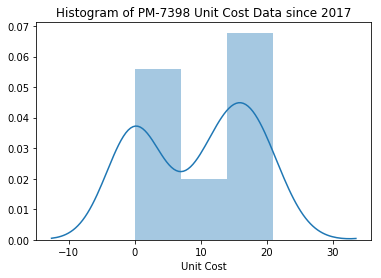

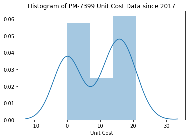

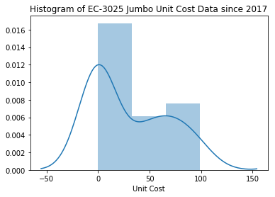

```python
plt.figure(1)
sns.distplot(ucPM7398['Unit Cost'])
plt.title('Histogram of PM-7398 Unit Cost Data since 2017')
plt.show(1)
plt.figure(2)
sns.distplot(ucPM7399['Unit Cost'])
plt.title('Histogram of PM-7399 Unit Cost Data since 2017')
plt.show(2)
plt.figure(3)
sns.distplot(ucEC3025['Unit Cost'])
plt.title('Histogram of EC-3025 Jumbo Unit Cost Data since 2017')
plt.show(3)
```

All of the Unit Cost Distributions here are Bimodal. This is because there are months/time periods for which these products do not run so the Unit Cost of the product for that month is zero. So I want to filter out these months because it will throw off the analysis.

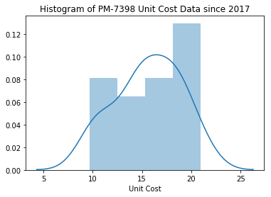

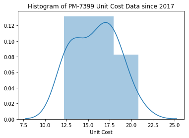

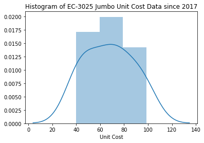

```python
ucPM7398f = ucPM7398['Unit Cost'] > 0
ucPM7398f = ucPM7398[ucPM7398f]
ucPM7399f = ucPM7399['Unit Cost'] > 0
ucPM7399f = ucPM7399[ucPM7399f]
ucEC3025f = ucEC3025['Unit Cost'] > 0
ucEC3025f = ucEC3025[ucEC3025f]

plt.figure(1)
sns.distplot(ucPM7398f['Unit Cost'])
plt.title('Histogram of PM-7398 Unit Cost Data since 2017')
plt.show(1)
plt.figure(2)
sns.distplot(ucPM7399f['Unit Cost'])
plt.title('Histogram of PM-7399 Unit Cost Data since 2017')
plt.show(2)
plt.figure(3)
sns.distplot(ucEC3025f['Unit Cost'])
plt.title('Histogram of EC-3025 Jumbo Unit Cost Data since 2017')
plt.show(3)
```

This data looks far more normal. Now with these subsetted dataframes, I will begin my multivariate regression analysis.

```python
ucPM7398f = ucPM7398f.drop(columns = ['AMN ID', 'Time Period'])
ucPM7399f = ucPM7399f.drop(columns = ['AMN ID', 'Time Period'])
ucEC3025f = ucEC3025f.drop(columns = ['AMN ID', 'Time Period'])
```

## Pairplot PM-7398

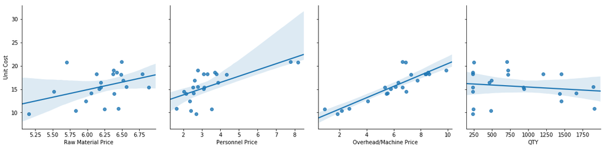

```python
sns.pairplot(ucPM7398f,
            x_vars = ['Raw Material Price','Personnel Price','Overhead/Machine Price','QTY'],
            y_vars = ['Unit Cost'],
            kind = "reg",
            height = 4)
plt.show()
```

PM-7398 shows a strong positive correlation between Unit Cost and Overhead/Machine Price. This seems to be the dominant factor on the PM-7398 unit cost.

There are slightly positive correlations between Unit Cost and Personnel Price along with Raw Material Price, but not as strong as Overhead/Machine Price

There is a weak negative correlation between Unit Cost and QTY.

## Pairplot PM-7399

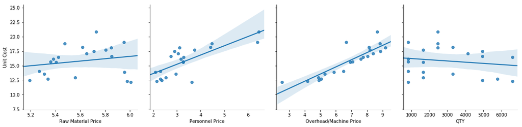

```python
sns.pairplot(ucPM7399f,
            x_vars = ['Raw Material Price','Personnel Price','Overhead/Machine Price','QTY'],
            y_vars = ['Unit Cost'],
            kind = "reg",
            height = 4)
plt.show()
```

PM-7399 shows similar correlations between Unit Cost and the four variables choosen as PM-7398. There is a strong positive correlation with Overhead/Machine Price followed by a moderate positive correlation with Personnel Price and then weak positive correlation with Raw Material Price.

There is a weak negative correlation between Unit Cost and QTY.

## Pairplot EC-3025 Jumbo

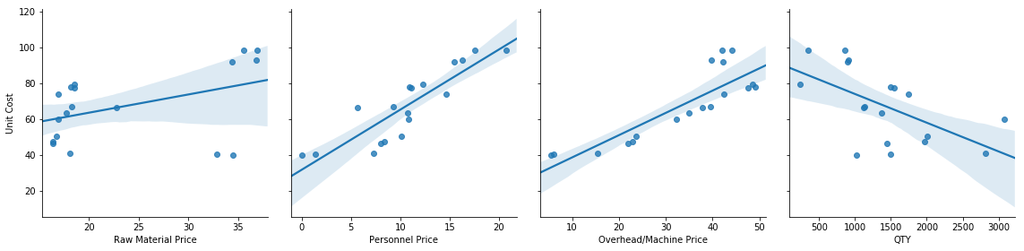

```python
sns.pairplot(ucEC3025f,
            x_vars = ['Raw Material Price','Personnel Price','Overhead/Machine Price','QTY'],
            y_vars = ['Unit Cost'],
            kind = "reg",
            height = 4)
plt.show()
```

The EC-3025 Jumbo data shows much stronger correlations with the 4 variables analyzed. The Personnel Price and Overhead/Machine Price seem to have similar strength postivie correlations with Unit Cost. The Raw Material Price has a more pronounced positive correlation compared to the PMs and there is a more defined negative correlation with QTY.

This indicates that the run length is having an impact on EC-3025 jumbo Unit Cost compared to the PMs made on the moguls and pony mixers.

## PM-7398 Correlation Heatmap

```
The Correlation Coefficients for respective variables to PM-7398 Unit Cost are:

 Overhead/Machine Price    0.877903
Personnel Price           0.653994
Raw Material Price        0.394073
QTY                      -0.152759
Name: Unit Cost, dtype: float64
```

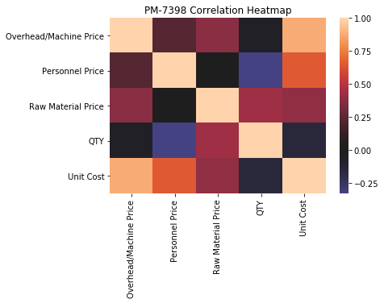

```python
corrpm7398 = ucPM7398f.corr()
rPM7398 = corrpm7398.loc[['Overhead/Machine Price','Personnel Price','Raw Material Price','QTY'],
                         'Unit Cost']
print('The Correlation Coefficients for respective variables to PM-7398 Unit Cost are: \n \n', rPM7398)

sns.heatmap(corrpm7398, center = 0)
plt.title('PM-7398 Correlation Heatmap')
plt.show()
```

## PM-7399 Correlation Heatmap

```
The Correlation Coefficients for respective variables to PM-7399 Unit Cost are:

 Overhead/Machine Price    0.876386
Personnel Price           0.757126
Raw Material Price        0.207687
QTY                      -0.161741
Name: Unit Cost, dtype: float64
```

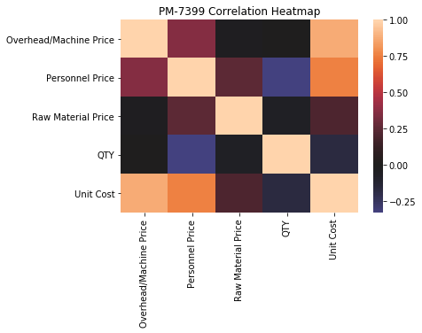

```python
corrpm7399 = ucPM7399f.corr()
rPM7399 = corrpm7399.loc[['Overhead/Machine Price','Personnel Price','Raw Material Price','QTY'],
                         'Unit Cost']
print('The Correlation Coefficients for respective variables to PM-7399 Unit Cost are: \n \n', rPM7399)

sns.heatmap(corrpm7399, center = 0)
plt.title('PM-7399 Correlation Heatmap')
plt.show()
```

## EC-3025 Correlation Heatmap

```
The Correlation Coefficients for respective variables to EC-3025 Jumbo Unit Cost are:

 Overhead/Machine Price    0.858012
Personnel Price           0.875008
Raw Material Price        0.428342
QTY                      -0.585001
Name: Unit Cost, dtype: float64
```

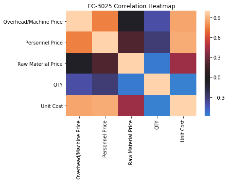

```python
correc3025 = ucEC3025f.corr()
rEC3025 = correc3025.loc[['Overhead/Machine Price','Personnel Price','Raw Material Price','QTY'],
                         'Unit Cost']
print('The Correlation Coefficients for respective variables to EC-3025 Jumbo Unit Cost are: \n \n', rEC3025)

sns.heatmap(correc3025, center = 0)
plt.title('EC-3025 Correlation Heatmap')
plt.show()
```